# Replication mediated genome rearrangements

Pierre Murat

07 October, 2024

This notebook reports the characterisation of origin-driven genome rearrangements and their consequences.

The previous sections demonstrate that PACA cluster 1 are characterised by a down regulation of G1/S and G2/M checkpoints and DNA break repair. These observations suggest the accumulation of SVs and CNVs breakpoints at origins of PACA 1 genomes.

We then focus on strutural variants (insertion & deletion >= 200bp). We distinguish between structural variants (SSVs) and copy number variants (CNVs). SSVs are supported by break ends. CNVs are mapped by conventional copy number ratio analysis.

# 1 Somatic structural variations in PACA cancer

This section focuses on structural variants supported by break end sequencing in cancer genomes. Because the number of SVs mapped per genome is small, we further characterise pan cancer trends. Part of the analysis is reported in 001_Mut_density_Pan_cancer_vX_X.Rmd

## 1.1 SV distibution at PACA origins

```r
# r

# Load SV coordinates with precomputed distances to origins
ICGC.SV.closest.ori.10kb.df <- read.table("./001_Mut_density_Pan_cancer/ICGC.SV.closest.ori.10kb.bed")
colnames(ICGC.SV.closest.ori.10kb.df) <- c("seqnames", "start", "end", "SV.id", "REF", "ALT", "SV.class", "donor", "project", "ori.seqnames", "ori.start", "ori.end", "EFF", "ori.id", "dist")
# distances are inverted
ICGC.SV.closest.ori.10kb.df$dist <- ICGC.SV.closest.ori.10kb.df$dist

# Load PACA cluster information
PACA.clusters.summary.df <- readRDS(file = "./003_Transcriptomics_cluster_analysis/rds/PACA.clusters.summary.df.rds")

# Filter SVs
PACA.SV.cluster.1.ori.10kb.df <- ICGC.SV.closest.ori.10kb.df %>% filter(donor %in% (PACA.clusters.summary.df %>% filter(cluster == "clust.1"))$donor) # 815 SVs
PACA.SV.cluster.2.ori.10kb.df <- ICGC.SV.closest.ori.10kb.df %>% filter(donor %in% (PACA.clusters.summary.df %>% filter(cluster == "clust.2"))$donor) # 1172 SVs
PACA.SV.cluster.3.ori.10kb.df <- ICGC.SV.closest.ori.10kb.df %>% filter(donor %in% (PACA.clusters.summary.df %>% filter(cluster == "clust.3"))$donor) # 10703 SVs

# Plot distribution of SVs around origins
# Because the data is noisy, due to the small number of SVs mapped, we count in bins of 200 bp

PACA.SV.cluster.1.ori.10kb.summary.df <- PACA.SV.cluster.1.ori.10kb.df %>% mutate(dist = (as.numeric(cut(dist, breaks = seq(-10000, 10000, 200)))-50)*200) %>%
  group_by(dist) %>% summarise(SV.count=n()) %>% mutate(cluster = "clust.1") %>% mutate(SV.FC = SV.count/mean(SV.count[c(1:20,180:200)], na.rm = T))
PACA.SV.cluster.2.ori.10kb.summary.df <- PACA.SV.cluster.2.ori.10kb.df %>% mutate(dist = (as.numeric(cut(dist, breaks = seq(-10000, 10000, 200)))-50)*200) %>%
  group_by(dist) %>% summarise(SV.count=n()) %>% mutate(cluster = "clust.2") %>% mutate(SV.FC = SV.count/mean(SV.count[c(1:20,180:200)], na.rm = T))
PACA.SV.cluster.3.ori.10kb.summary.df <- PACA.SV.cluster.3.ori.10kb.df %>% mutate(dist = (as.numeric(cut(dist, breaks = seq(-10000, 10000, 200)))-50)*200) %>%
  group_by(dist) %>% summarise(SV.count=n()) %>% mutate(cluster = "clust.3") %>% mutate(SV.FC = SV.count/mean(SV.count[c(1:20,180:200)], na.rm = T))
PACA.SV.cluster.ori.10kb.summary.df <- rbind(PACA.SV.cluster.1.ori.10kb.summary.df, PACA.SV.cluster.2.ori.10kb.summary.df, PACA.SV.cluster.3.ori.10kb.summary.df)
saveRDS(PACA.SV.cluster.ori.10kb.summary.df, file = "./004_Genome_rearrangements/rds/PACA.SV.cluster.ori.10kb.summary.df.rds")
```

Plot

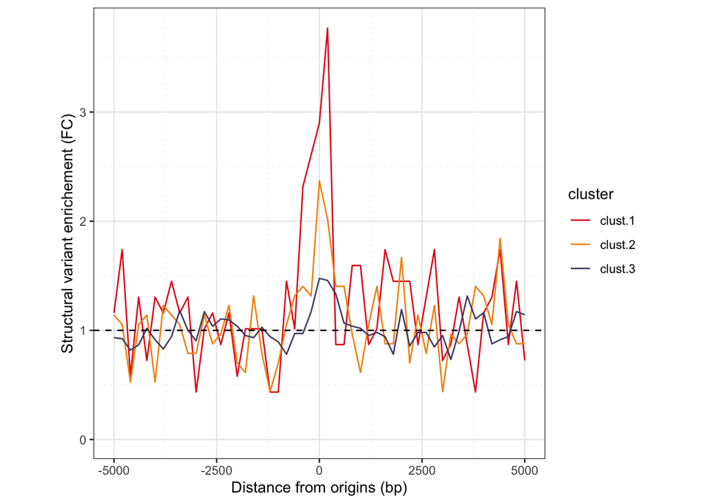

```r
library(dplyr)
library(ggplot2)
setwd("/Users/pm23/Desktop/Projects/OriCan")

PACA.SV.cluster.ori.10kb.summary.df <- readRDS(file = "./004_Genome_rearrangements/rds/PACA.SV.cluster.ori.10kb.summary.df.rds")
PACA.SV.cluster.ori.10kb.summary.plot <- PACA.SV.cluster.ori.10kb.summary.df %>%
  ggplot(aes(x = dist, y = SV.FC , color = cluster)) +
  geom_line() + xlim(-5000,5000) + #ylim(0.4, 4) +
  scale_color_manual(values = c("#E4221E", "#F39208", "#504B76")) +
  geom_hline(yintercept=1, linetype="dashed") +
  xlab("Distance from origins (bp)") + ylab("Structural variant enrichement (FC)") +
  theme_bw() + theme(aspect.ratio=1, panel.grid.minor = element_line(linetype = "dotted"))
PACA.SV.cluster.ori.10kb.summary.plot
```

```r
pdf("./Rplots/PACA.SV.cluster.enrichment.pdf", width=10, height=6, useDingbats=FALSE)
PACA.SV.cluster.ori.10kb.summary.plot
dev.off()
```

## 1.2 SV enrichement at G4s

Map SV break ends associated to tandem duplication at G-quadruplexes. Due to the limited number of SV in PACA, we consider all mapped SVs.

```r
# r

# Recover coordinates of the duplicated fragments
ICGC.DUP.df <- annoSV.ori.dist.df %>% filter(svtype == "DUP") # 13,740 events
ICGC.DUP.df <- ICGC.DUP.df[grepl("]", ICGC.DUP.df$ALT),] # 6,873 events
# orient fragments
ICGC.DUP.df <- ICGC.DUP.df %>%
  mutate(start.oriented = case_when(dist.ori <= 0 ~ start, dist.ori >= 0 ~ end), end.oriented = start.oriented+1) %>%
  dplyr::select(seqnames, start = start.oriented, end = end.oriented, REF, ALT, donor)
ICGC.DUP.gr <- makeGRangesFromDataFrame(ICGC.SV.df, keep.extra.columns = T) # 13,740 SVs
seqlevelsStyle(ICGC.DUP.gr) <- "UCSC"

# Compute distances to G4 either at origins or in the flanks
# G4 are also oriented

# Load G4 distances information for G4s at origin domain
G4.ori.dist.gr <- readRDS(file = "./002_Mut_signatures_Pan_cancer/rds/G4.ori.dist.gr.rds")

# Compute G4 distances for G4 at origin flanks
G4.score.flanks.gr <- readRDS(file = "./002_Mut_signatures_Pan_cancer/rds/G4.score.flanks.filter.gr.rds")

G4.flanks.dist <- nearest(G4.score.flanks.gr, ori.inter.dist.gr)
flanks.dist.gr <- ori.inter.dist.gr[G4.flanks.dist]
G4.flanks.dist.gr <- as.data.frame(G4.score.flanks.gr) %>% mutate(flanks.pos = start(flanks.dist.gr), flanks.dist = start-flanks.pos) %>%
  mutate(flanks.pos = case_when(flanks.dist <= 0 ~ "upstream", T ~ "downtream")) %>%
  mutate(rep.strand = case_when((flanks.pos == "upstream" & class == "G4") ~ "leading",
                                (flanks.pos == "downtream" & class == "C4") ~ "leading",
                                T ~ "lagging")) %>%
  makeGRangesFromDataFrame(keep.extra.columns = T)
saveRDS(G4.flanks.dist.gr, file = "./002_Mut_signatures_Pan_cancer/rds/G4.flanks.dist.gr.rds")

# Compute break end distances to G4s

# At origins
ICGC.DUP.G4.ori.dist <- nearest(ICGC.DUP.gr, G4.ori.dist.gr)
G4.start <- start(G4.ori.dist.gr[ICGC.DUP.G4.ori.dist])+7
G4.end <- end(G4.ori.dist.gr[ICGC.DUP.G4.ori.dist])-7
G4.ori.dist <- G4.ori.dist.gr[ICGC.DUP.G4.ori.dist]$ori.dist
G4.class <- G4.ori.dist.gr[ICGC.DUP.G4.ori.dist]$class
ICGC.DUP.G4.ori.dist.df <- cbind.data.frame(as.data.frame(ICGC.DUP.gr), G4.start, G4.end, G4.ori.dist, G4.class) %>%
  mutate(G4.DUP.dist = case_when(G4.ori.dist < 0 ~ G4.end-start,
                                G4.ori.dist > 0 ~ G4.start-start)) %>% filter(G4.DUP.dist >= -1000 & G4.DUP.dist <= 1000)
saveRDS(ICGC.DUP.G4.ori.dist.df, file = "./004_Genome_rearrangements/rds/ICGC.DUP.G4.ori.dist.df.rds")

# At origin flanks
ICGC.DUP.G4.flanks.dist <- nearest(ICGC.DUP.gr, G4.flanks.dist.gr)
G4.start <- start(G4.flanks.dist.gr[ICGC.DUP.G4.flanks.dist])+7
G4.end <- end(G4.flanks.dist.gr[ICGC.DUP.G4.flanks.dist])-7
G4.ori.dist <- G4.flanks.dist.gr[ICGC.DUP.G4.flanks.dist]$flanks.dist
G4.class <- G4.flanks.dist.gr[ICGC.DUP.G4.flanks.dist]$class
ICGC.DUP.G4.flanks.dist.df <- cbind.data.frame(as.data.frame(ICGC.DUP.gr), G4.start, G4.end, G4.ori.dist, G4.class) %>%
  mutate(G4.DUP.dist = case_when(G4.ori.dist < 0 ~ G4.end-start,
                                G4.ori.dist > 0 ~ G4.start-start)) %>% filter(G4.DUP.dist >= -1000 & G4.DUP.dist <= 1000)
saveRDS(ICGC.DUP.G4.flanks.dist.df, file = "./004_Genome_rearrangements/rds/ICGC.DUP.G4.flanks.dist.df.rds")
```

Plot

```r
library(dplyr)
library(ggplot2)
library(ggpubr)
setwd("/Users/pm23/Desktop/Projects/OriCan")

ICGC.DUP.G4.ori.dist.df <- readRDS(file = "./004_Genome_rearrangements/rds/ICGC.DUP.G4.ori.dist.df.rds")
ICGC.DUP.G4.flanks.dist.df <- readRDS(file = "./004_Genome_rearrangements/rds/ICGC.DUP.G4.flanks.dist.df.rds")

DUP.G4.ori.dist.plot <- ICGC.DUP.G4.ori.dist.df %>% ggplot(aes(x=G4.DUP.dist)) +
  geom_histogram(binwidth=5, fill="#D56014", color="#010101", linewidth = 0.25) + xlab("Distance from G4 (nt)") + ylab("Break ends count") + xlim(-250,250) + ylim(0, 125) +
  theme_bw() + theme(aspect.ratio=0.5, panel.grid.minor = element_line(linetype = "dotted")) + ggtitle("At origins, n = 69914")

DUP.G4.flanks.dist.plot <- ICGC.DUP.G4.flanks.dist.df %>% ggplot(aes(x=G4.DUP.dist)) +
  geom_histogram(binwidth=5, fill="#504B76", color="#010101", linewidth = 0.25) + xlab("Distance from G4 (nt)") + ylab("Break ends count") + xlim(-250,250) + ylim(0, 125) +
  theme_bw() + theme(aspect.ratio=0.5, panel.grid.minor = element_line(linetype = "dotted")) + ggtitle("At origin flankss, n = 179962")

pdf("./Rplots/SV.break.ends.G4.pdf", width=8, height=6, useDingbats=FALSE)
ggarrange(DUP.G4.ori.dist.plot, DUP.G4.flanks.dist.plot, nrow = 2, ncol = 1)
dev.off()
```

Assess the nature of breakpoints

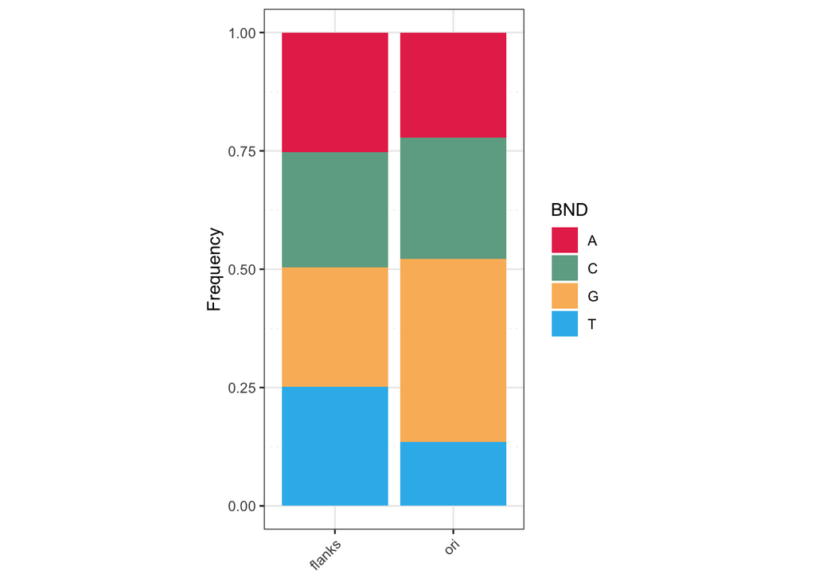

```r
library(dplyr)
library(ggplot2)
setwd("/Users/pm23/Desktop/Projects/OriCan")

ICGC.DUP.G4.ori.dist.df <- readRDS(file = "./004_Genome_rearrangements/rds/ICGC.DUP.G4.ori.dist.df.rds")
ICGC.DUP.G4.flanks.dist.df <- readRDS(file = "./004_Genome_rearrangements/rds/ICGC.DUP.G4.flanks.dist.df.rds")

# At origins
ICGC.DUP.ori.BND.df <- ICGC.DUP.G4.ori.dist.df %>%
                                   mutate(BND = case_when(G4.class == "C4" & REF =="G" ~ "C",
                                                          G4.class == "C4" & REF =="C" ~ "G",
                                                          G4.class == "C4" & REF =="A" ~ "T",
                                                          G4.class == "C4" & REF =="T" ~ "A",
                                                          T ~ REF))
ICGC.DUP.ori.table <- as.data.frame(table(ICGC.DUP.ori.BND.df$BND))
colnames(ICGC.DUP.ori.table) <- c("BND", "count")
ICGC.DUP.ori.table <- ICGC.DUP.ori.table %>% mutate(freq = count/sum(count), class = "ori")

# At flanks
ICGC.DUP.flanks.BND.df <- ICGC.DUP.G4.flanks.dist.df %>%
                                   mutate(BND = case_when(G4.class == "C4" & REF =="G" ~ "C",
                                                          G4.class == "C4" & REF =="C" ~ "G",
                                                          G4.class == "C4" & REF =="A" ~ "T",
                                                          G4.class == "C4" & REF =="T" ~ "A",
                                                          T ~ REF))
ICGC.DUP.flanks.table <- as.data.frame(table(ICGC.DUP.flanks.BND.df$BND))
  colnames(ICGC.DUP.flanks.table) <- c("BND", "count")
ICGC.DUP.flanks.table <- ICGC.DUP.flanks.table %>% mutate(freq = count/sum(count), class = "flanks")

# Combine results
ICGC.DUP.BND.table <- rbind(ICGC.DUP.ori.table, ICGC.DUP.flanks.table)

# Plot
ICGC.DUP.BND.table.plot <- ICGC.DUP.BND.table %>% ggplot(aes(fill=BND, y=freq, x=class)) +
  geom_bar(position="stack", stat="identity") + ylab("Frequency") +
  scale_fill_manual(values = c("#E73458", "#6FAA93", "#FAB967", "#32B9EC")) +
  theme_bw() + theme(aspect.ratio=2, panel.grid.minor = element_line(linetype = "dotted"), axis.title.x=element_blank(), axis.text.x=element_text(angle=45,hjust=1))
ICGC.DUP.BND.table.plot
```

```r
pdf("./Rplots/ICGC.DUP.BND.table.plot.pdf", width=7, height=6, useDingbats=FALSE)
ICGC.DUP.BND.table.plot
dev.off()
```

## 1.3 Functional characterisation of tandem duplication events

This section aims to assess the overlap of duplicated regions with genes and CRE.

```r
# r
library(TxDb.Hsapiens.UCSC.hg19.knownGene)

# Recover the coordinates of duplicated segments at origins
DUP.ori.df <- annoSV.ori.dist.df %>% filter(svtype == "DUP") %>% filter(dist.ori  >= -500 & dist.ori  <= 500)
DUP.ori.gr <- makeGRangesFromDataFrame(DUP.ori.df, keep.extra.columns = T)
seqlevelsStyle(DUP.ori.gr) <- "UCSC"

# Identify closest genes
hsapiens.coding.genes <- readRDS("./003_Transcriptomics_cluster_analysis/rds/hsapiens.coding.genes.rds")
txdb <- TxDb.Hsapiens.UCSC.hg19.knownGene
hsapiens.genes.gr <- genes(txdb)
hsapiens.coding.genes.gr <- hsapiens.genes.gr[hsapiens.genes.gr$gene_id %in% hsapiens.coding.genes$ncbi.gene.id]
DUP.gene.nearest <- distanceToNearest(DUP.ori.gr, hsapiens.coding.genes.gr)
DUP.gene.nearest.df <- cbind.data.frame(as.data.frame(DUP.ori.gr), ncbi.gene.id = as.numeric(hsapiens.coding.genes.gr[subjectHits(DUP.gene.nearest)]$gene_id), dist = DUP.gene.nearest@elementMetadata$distance) %>% left_join(hsapiens.coding.genes, by = "ncbi.gene.id")
saveRDS(DUP.gene.nearest.df, file = "./004_Genome_rearrangements/rds/DUP.gene.nearest.df.rds")
```

The previous analysis reveals tandem duplication of sequences of functional interest. For example: - a 40 nt long sequence at 92 nt upstream of the ESR2 (Estrogen receptor) gene in PACA1. - a 105 nt long sequence in the first intron of MYC for DO27769 (MALY-DE). - a 112 nt long sequence in the first intron of TYK2 (tyrosine kinase - JAK) for DO35613 (PBCA-DE).

# 2 Somatic copy number alterations in PACA cancer

This section focuses on characerising CNA in PACA genomes.

## 2.1 CNR file formatting

PACA donor CNSM data was downloaded from the ICGC website.

Format table

```r
# r

# Load data
PACA.CNA.df <- read.csv(gzfile("./Dataset/ICGC/PACA/copy_number_somatic_mutation.tsv.gz"), sep = "\t") # 483,808 entries

# Segment CNR values are either indicated in the mean or the median column. We create a new column to take either value in consideration
PACA.CNA.df$segment.mean <- rowSums(PACA.CNA.df[,c("segment_mean", "segment_median")], na.rm=TRUE)

# Prepare light table
PACA.CNA.light.df <- PACA.CNA.df %>%
  dplyr::select(seqnames = chromosome, start = chromosome_start, end = chromosome_end, donor = icgc_donor_id, mutation.type = mutation_type, copy.number = copy_number, segment.mean = segment.mean)

length(unique(PACA.CNA.light.df$donor)) # 460 donors

# Add PACA cluster information
PACA.clusters.summary.df <- readRDS(file = "./003_Transcriptomics_cluster_analysis/rds/PACA.clusters.summary.df.rds")
PACA.clusters.summary.light.df <- PACA.clusters.summary.df %>% dplyr::select(donor, cluster)
PACA.CNA.light.df <- PACA.CNA.light.df %>% filter(donor %in% PACA.clusters.summary.light.df$donor) %>% left_join(PACA.clusters.summary.light.df, by = "donor") %>% distinct()

# Save
saveRDS(PACA.CNA.light.df, file = "./004_Genome_rearrangements/rds/ICGC.PACA.CNA.df.rds")
```

## 2.2 CNV occurences

Characterise the nature and extend of CNR fragments in PACA genomes.

In this section we consider only fragments longer than 500kb.

[figure not shown]

```r
library(dplyr)
library(ggplot2)
library(ggpubr)
library(scales)
library(forcats)
setwd("/Users/pm23/Desktop/Projects/OriCan")

###########################################################
# Count number of segments and their median length per genome per clusters

# Load data

ICGC.PACA.CNA.df <- readRDS(file = "./004_Genome_rearrangements/rds/ICGC.PACA.CNA.df.rds")

# Summarise data

PACA.segment.count.df <- ICGC.PACA.CNA.df %>% filter(end-start >= 500000) %>% group_by(donor, cluster) %>% summarise(segment.count = n(), segment.length = median((end-start)/1000, na.rm = T))
saveRDS(PACA.segment.count.df, file = "./004_Genome_rearrangements/rds/PACA.segment.count.df.rds")

# Plot

PACA.segment.count.plot <- PACA.segment.count.df %>% ggplot(aes(x=cluster, y=segment.count)) +
  geom_boxplot(aes(fill = cluster), alpha = 0.5, outlier.shape = NA) + geom_jitter(alpha = 0.2) +
  scale_fill_manual(values = c("#E41F1A", "#F39200", "#4F4A75")) + ylab("CNR segment count") +
  scale_y_continuous(trans = log10_trans(), limits = c(50,4000)) +
  ggtitle("Pval = 0.8315 & 1.261e-08") +
  theme_bw() + theme(aspect.ratio = 2, axis.title.x=element_blank(), legend.position = "none", axis.text.x = element_text(angle = 45, hjust = 0.5, vjust = 0.5))
PACA.segment.count.plot
```

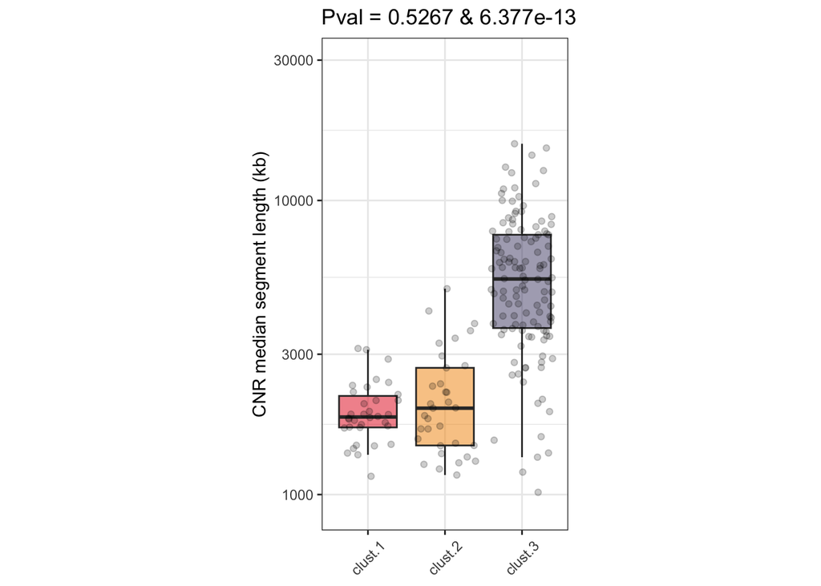

```r
PACA.segment.length.plot <- PACA.segment.count.df %>% ggplot(aes(x=cluster, y=segment.length)) +
  geom_boxplot(aes(fill = cluster), alpha = 0.5, outlier.shape = NA) + geom_jitter(alpha = 0.2) +
  scale_fill_manual(values = c("#E41F1A", "#F39200", "#4F4A75")) + ylab("CNR median segment length (kb)") +
  scale_y_continuous(trans = log10_trans(), limits = c(900,30000)) +
  ggtitle("Pval = 0.5267 & 6.377e-13") +
  theme_bw() + theme(aspect.ratio = 2, axis.title.x=element_blank(), legend.position = "none", axis.text.x = element_text(angle = 45, hjust = 0.5, vjust = 0.5))
PACA.segment.length.plot
```

```r
# Statistics
ks.test(PACA.segment.count.df[which(PACA.segment.count.df$cluster == "clust.1"),]$segment.count,
        PACA.segment.count.df[which(PACA.segment.count.df$cluster == "clust.2"),]$segment.count) # p-value = 0.8315
```

[output not shown]

```r
ks.test(PACA.segment.count.df[which(PACA.segment.count.df$cluster == "clust.2"),]$segment.count,
        PACA.segment.count.df[which(PACA.segment.count.df$cluster == "clust.3"),]$segment.count) # p-value = 1.261e-08
```

[output not shown]

```r
ks.test(PACA.segment.count.df[which(PACA.segment.count.df$cluster == "clust.1"),]$segment.length,
        PACA.segment.count.df[which(PACA.segment.count.df$cluster == "clust.2"),]$segment.length) # p-value = 0.5267
```

```
##
##  Exact two-sample Kolmogorov-Smirnov test
##
## data:  PACA.segment.count.df[which(PACA.segment.count.df$cluster == "clust.1"), ]$segment.length and PACA.segment.count.df[which(PACA.segment.count.df$cluster == "clust.2"), ]$segment.length
## D = 0.18806, p-value = 0.5267
## alternative hypothesis: two-sided
```

```r
ks.test(PACA.segment.count.df[which(PACA.segment.count.df$cluster == "clust.2"),]$segment.length,
        PACA.segment.count.df[which(PACA.segment.count.df$cluster == "clust.3"),]$segment.length) # p-value = 6.377e-13
```

[output not shown]

```r
# Save plots

pdf("./Rplots/PACA.segment.summary.plot.pdf", width=12, height=5, useDingbats=FALSE)
ggarrange(PACA.segment.count.plot, PACA.segment.length.plot, nrow=1)
dev.off()
```

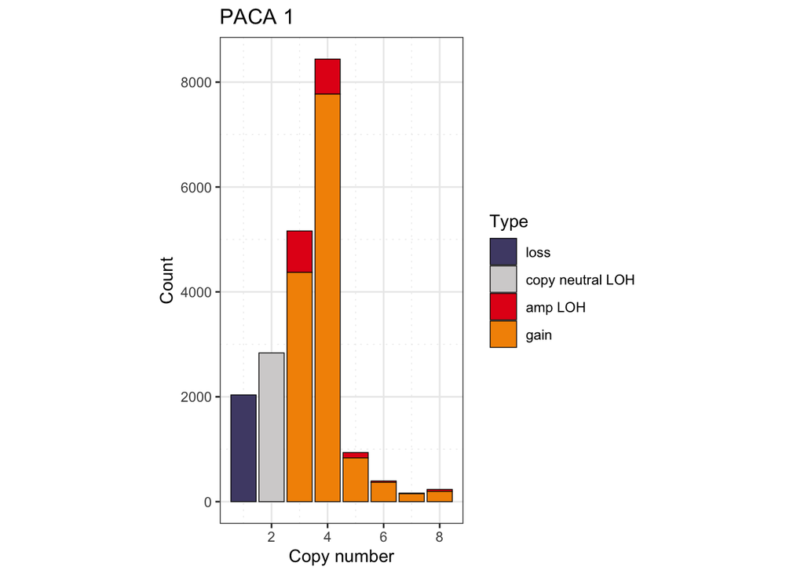

```r
###########################################################
# Assess CNV mutation types for PACA genomes

# Summarise data

# Plot by PACA clusters

ICGC.PACA.CNA.mut.type.df <- ICGC.PACA.CNA.df %>% filter(end-start >= 500000) %>% filter(copy.number %in% c(1:10)) %>%
  group_by(cluster, copy.number, mutation.type) %>% summarise(count = n()) %>% mutate(freq = count/sum(count))

ICGC.PACA.CNA.mut.type.PACA.1.plot <- ICGC.PACA.CNA.mut.type.df %>% filter(cluster == "clust.1") %>%
  mutate(Type = fct_relevel(mutation.type, "loss", "copy neutral LOH", "amp LOH", "gain")) %>%
      ggplot(aes(fill=Type, y=count, x=copy.number)) +
      geom_bar(position="stack", stat="identity", linewidth = 0.25, color="#010101") + xlab("Copy number") + ylab("Count") + ggtitle("PACA 1") +
      scale_fill_manual(values = c("#4F4A75", "#D4D2D2", "#E41F1A", "#F39200")) +
      theme_bw() + theme(aspect.ratio=2, panel.grid.minor = element_line(linetype = "dotted"))
ICGC.PACA.CNA.mut.type.PACA.1.plot
```

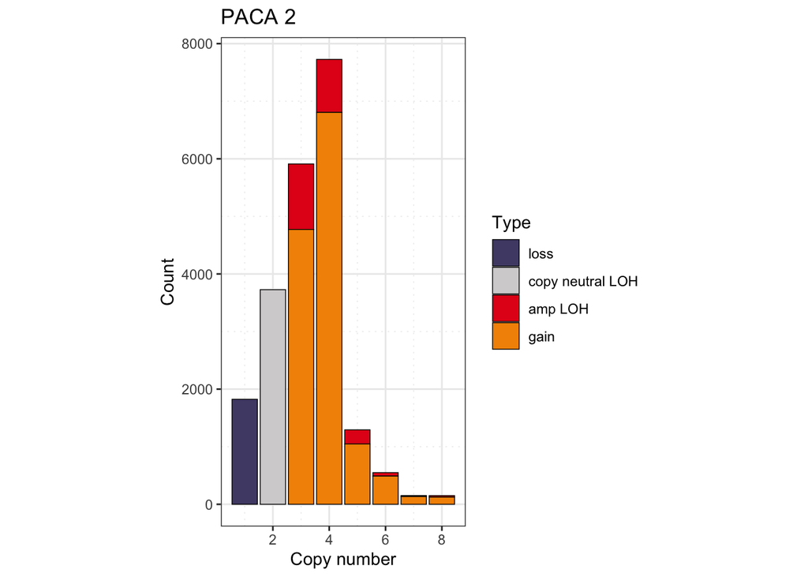

```r
ICGC.PACA.CNA.mut.type.PACA.2.plot <- ICGC.PACA.CNA.mut.type.df %>% filter(cluster == "clust.2") %>%
  mutate(Type = fct_relevel(mutation.type, "loss", "copy neutral LOH", "amp LOH", "gain")) %>%
      ggplot(aes(fill=Type, y=count, x=copy.number)) +
      geom_bar(position="stack", stat="identity", linewidth = 0.25, color="#010101") + xlab("Copy number") + ylab("Count") + ggtitle("PACA 2") +
      scale_fill_manual(values = c("#4F4A75", "#D4D2D2", "#E41F1A", "#F39200")) +
      theme_bw() + theme(aspect.ratio=2, panel.grid.minor = element_line(linetype = "dotted"))
ICGC.PACA.CNA.mut.type.PACA.2.plot
```

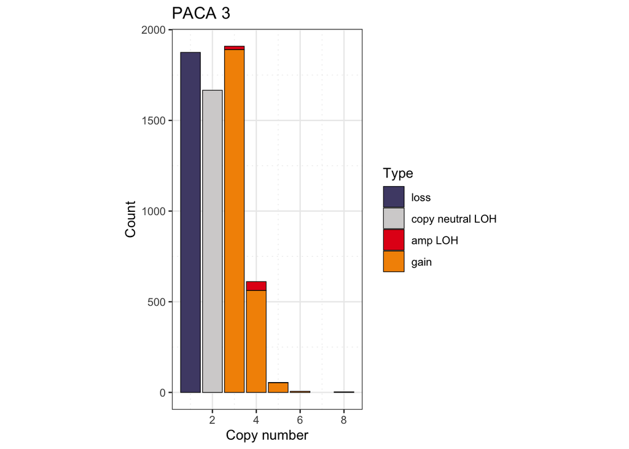

```r
ICGC.PACA.CNA.mut.type.PACA.3.plot <- ICGC.PACA.CNA.mut.type.df %>% filter(cluster == "clust.3") %>%
  mutate(Type = fct_relevel(mutation.type, "loss", "copy neutral LOH", "amp LOH", "gain")) %>%
      ggplot(aes(fill=Type, y=count, x=copy.number)) +
      geom_bar(position="stack", stat="identity", linewidth = 0.25, color="#010101") + xlab("Copy number") + ylab("Count") + ggtitle("PACA 3") +
      scale_fill_manual(values = c("#4F4A75", "#D4D2D2", "#E41F1A", "#F39200")) +
      theme_bw() + theme(aspect.ratio=2, panel.grid.minor = element_line(linetype = "dotted"))
ICGC.PACA.CNA.mut.type.PACA.3.plot
```

```r
# Save plots

pdf("./Rplots/PACA.segment.type.plot.pdf", width=12, height=5, useDingbats=FALSE)
ggarrange(ICGC.PACA.CNA.mut.type.PACA.1.plot, ICGC.PACA.CNA.mut.type.PACA.2.plot, ICGC.PACA.CNA.mut.type.PACA.3.plot, nrow=1)
dev.off()
```

## 2.3 CNV signatures

Extract CNV signatures from PACA tumours according to the nomenclature introduced in Steele et al. Nature, 2022, 606, 984 (https://www.nature.com/articles/s41586-022-04738-6). Length and copy number inervals have been slightly modified to higlight differences bewteen PACA clusters.

```r
# r

# Load results
ICGC.PACA.CNA.df <- readRDS(file = "./004_Genome_rearrangements/rds/ICGC.PACA.CNA.df.rds")

# We consider each type of CNV binned in 7 length intervals
# Loss events are counted without considering CNV length

CNV.sig.df <- ICGC.PACA.CNA.df %>% filter(mutation.type != "undetermined") %>%
  mutate(mutation.type = case_when(mutation.type == "loss" & copy.number >= 0.8 & copy.number <= 1.2 ~ "hemizygous del LOH",
                                   mutation.type == "copy neutral" & copy.number >= 0.8 & copy.number <= 1.2 ~ "hemizygous del LOH",
                                   mutation.type == "loss" & copy.number >= -0.2 & copy.number <= 0.2 ~ "loss",
                                   T ~ mutation.type)) %>%
  mutate(cnvHet = case_when(mutation.type == "copy neutral LOH" | mutation.type == "amp LOH" | mutation.type == "hemizygous del LOH" ~ "LOH",
                            mutation.type == "loss" ~ "0",
                            T ~ "Het")) %>% filter(cnvHet != "NA") %>%
  mutate(cp = case_when(mutation.type == "loss" ~ "0",
                        copy.number >= 0.8 & copy.number <= 1.2 ~ "1",
                        copy.number >= 1.8 & copy.number <= 2.2 ~ "2",
                        copy.number >= 2.8 & copy.number <= 3.2 ~ "3",
                        copy.number >= 3.8 & copy.number <= 4.2 ~ "4-5",
                        copy.number >= 4.8 & copy.number <= 5.2 ~ "4-5",
                        copy.number > 5.8 ~ "6+",
                        T ~ NA)) %>% filter(cp != "NA") %>%
  mutate(cnvlength = case_when(abs(end-start) >= 0 & abs(end-start) <= 100e3 ~ "0-0.1Mb",
                               abs(end-start) > 100e3 & abs(end-start) <= 1e6 ~ "0.1-1Mb",
                               abs(end-start) > 1e6 & abs(end-start) <= 2e6 ~ "1-2Mb",
                               abs(end-start) > 2e6 & abs(end-start) <= 3e6 ~ "2-3Mb",
                               abs(end-start) > 3e6 & abs(end-start) <= 5e6 ~ "3-5Mb",
                               abs(end-start) > 5e6 & abs(end-start) <= 10e6 ~ "5-10Mb",
                               abs(end-start) > 10e6 ~ ">10Mb",
                               mutation.type == "loss" ~ "loss",
                               T ~ NA)) %>% filter(cnvlength != "NA") %>%
  mutate(sig = paste(cnvHet, cp, cnvlength, sep = "_"))
# Change all cp 0 to loss
CNV.sig.df[grepl("0", CNV.sig.df$cp),]$cnvHet <- 0
# CNV.sig.df[grepl("0", CNV.sig.df$cp),]$sig <- 0

#
# temp <- CNV.sig.df %>% filter(cp == 0)
# hist(log10(temp$end-temp$start), breaks = 100, xlim =c(1,9))

# Prepare empty table
cnvHet <- c("LOH", "Het")
cp <- c("0", "1", "2", "3", "4-5", "6+")
cnvlength <- c("0-0.1Mb", "0.1-1Mb", "1-2Mb", "2-3Mb", "3-5Mb", "5-10Mb", "5-10Mb", ">10Mb")
CNV.sig.init.df <- expand.grid(cnvHet, cp, cnvlength)
colnames(CNV.sig.init.df) <- c("cnvHet", "cp", "cnvlength")
CNV.sig.init.df <- rbind(CNV.sig.init.df, cbind(cnvlength = "loss", cnvHet = "0", cp = "0")) %>% mutate(sig = paste(cnvHet, cp, cnvlength, sep = "_"))
# Change all cp 0 to loss
CNV.sig.init.df[grepl("0", CNV.sig.init.df$cp),]$cnvHet <- 0
# CNV.sig.init.df[grepl("0", CNV.sig.init.df$cp),]$sig <- 0
# Remove extra signatures associated to cp 0
CNV.sig.init.df <- CNV.sig.init.df[!grepl("Het_0", CNV.sig.init.df$sig),]
# Remove extra signatures associated to cp 1-Het
CNV.sig.init.df <- CNV.sig.init.df[!grepl("Het_1", CNV.sig.init.df$sig),]

# PACA1 CNV signature
PACA1.CNV.sig.df <- CNV.sig.df %>% filter(cluster == "clust.1") %>% group_by(sig) %>% summarise(count = n()) %>%
  right_join(CNV.sig.init.df, by = "sig") %>% ungroup() %>% mutate(freq = count/sum(count, na.rm = T)) %>% dplyr::select(-count)
PACA1.CNV.sig.df[is.na(PACA1.CNV.sig.df)] <- 0
saveRDS(PACA1.CNV.sig.df, file = "./004_Genome_rearrangements/rds/PACA1.CNV.sig.df.rds")

# PACA2 CNV signature
PACA2.CNV.sig.df <- CNV.sig.df %>% filter(cluster == "clust.2") %>% group_by(cnvlength, cnvHet, cp) %>% summarise(count = n()) %>%
  right_join(CNV.sig.init.df, by = c("cnvlength", "cnvHet", "cp")) %>% ungroup() %>% mutate(freq = count/sum(count, na.rm = T)) %>% dplyr::select(-count)
PACA2.CNV.sig.df[is.na(PACA2.CNV.sig.df)] <- 0
saveRDS(PACA2.CNV.sig.df, file = "./004_Genome_rearrangements/rds/PACA2.CNV.sig.df.rds")

# PACA1 PACA2 mixed CNV signature
PACA1.PACA2.CNV.sig.df <- CNV.sig.df %>% filter(cluster == "clust.1" | cluster == "clust.2") %>% group_by(sig) %>% summarise(count = n()) %>%
  right_join(CNV.sig.init.df, by = "sig") %>% ungroup() %>% mutate(freq = count/sum(count, na.rm = T)) %>% dplyr::select(-count)
PACA1.PACA2.CNV.sig.df[is.na(PACA1.PACA2.CNV.sig.df)] <- 0
saveRDS(PACA1.PACA2.CNV.sig.df, file = "./004_Genome_rearrangements/rds/PACA1.PACA2.CNV.sig.df.rds")

# PACA3 CNV signature
PACA3.CNV.sig.df <- CNV.sig.df %>% filter(cluster == "clust.3") %>% group_by(cnvlength, cnvHet, cp) %>% summarise(count = n()) %>%
  right_join(CNV.sig.init.df, by = c("cnvlength", "cnvHet", "cp")) %>% ungroup() %>% mutate(freq = count/sum(count, na.rm = T)) %>% dplyr::select(-count)
PACA3.CNV.sig.df[is.na(PACA3.CNV.sig.df)] <- 0
saveRDS(PACA3.CNV.sig.df, file = "./004_Genome_rearrangements/rds/PACA3.CNV.sig.df.rds")
```

Plot

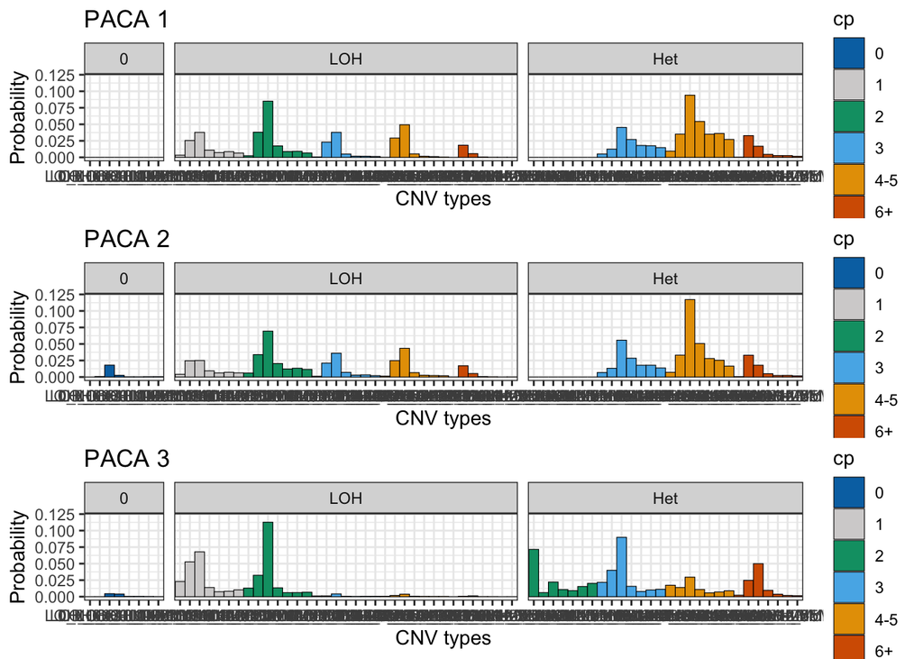

```r
library(dplyr)
library(tidyr)
library(ggplot2)
library(forcats)
library(ggpubr)
setwd("/Users/pm23/Desktop/Projects/OriCan")

# Load results
PACA1.CNV.sig.df <- readRDS("./004_Genome_rearrangements/rds/PACA1.CNV.sig.df.rds")
PACA2.CNV.sig.df <- readRDS("./004_Genome_rearrangements/rds/PACA2.CNV.sig.df.rds")
PACA1.PACA2.CNV.sig.df <- readRDS("./004_Genome_rearrangements/rds/PACA1.PACA2.CNV.sig.df.rds")
PACA3.CNV.sig.df <- readRDS("./004_Genome_rearrangements/rds/PACA3.CNV.sig.df.rds")

# Plot

PACA1.CNV.sig.plot <- PACA1.CNV.sig.df %>% distinct() %>%
  mutate(CNVlength = fct_relevel(cnvlength, "0-0.1Mb", "0.1-1Mb", "1-2Mb", "2-3Mb", "3-5Mb", "5-10Mb", ">10Mb")) %>%
  mutate(CNVHet = fct_relevel(cnvHet, "0", "LOH", "Het")) %>%
  ggplot(aes(x = sig, y = freq, fill = cp, width = 1)) +
  geom_bar(stat = "identity", colour = "black", size = .2) + ylim(0,0.12) + ylab("Probability") + xlab("CNV types") + ggtitle("PACA 1") +
  scale_fill_manual(values = c("#0072B2", "#D4D2D2", "#009E73", "#56B4E9", "#E69F00", "#D55E00")) +
  theme_bw() + facet_grid(.~CNVHet, space = "free", scales = "free_x")

PACA2.CNV.sig.plot <- PACA2.CNV.sig.df %>% distinct() %>%
  mutate(CNVlength = fct_relevel(cnvlength, "0-0.1Mb", "0.1-1Mb", "1-2Mb", "2-3Mb", "3-5Mb", "5-10Mb", ">10Mb")) %>%
  mutate(CNVHet = fct_relevel(cnvHet, "0", "LOH", "Het")) %>%
  ggplot(aes(x = sig, y = freq, fill = cp, width = 1)) +
  geom_bar(stat = "identity", colour = "black", size = .2) + ylim(0,0.12) + ylab("Probability") + xlab("CNV types") + ggtitle("PACA 2") +
  scale_fill_manual(values = c("#0072B2", "#D4D2D2", "#009E73", "#56B4E9", "#E69F00", "#D55E00")) +
  theme_bw() + facet_grid(.~CNVHet, space = "free", scales = "free_x")

PACA1.PACA2.CNV.sig.plot <- PACA1.PACA2.CNV.sig.df %>% distinct() %>%
  mutate(CNVlength = fct_relevel(cnvlength, "0-0.1Mb", "0.1-1Mb", "1-2Mb", "2-3Mb", "3-5Mb", "5-10Mb", ">10Mb")) %>%
  mutate(CNVHet = fct_relevel(cnvHet, "0", "LOH", "Het")) %>%
  ggplot(aes(x = sig, y = freq, fill = cp, width = 1)) +
  geom_bar(stat = "identity", colour = "black", size = .2) + ylim(0,0.12) + ylab("Probability") + xlab("CNV types") + ggtitle("PACA 1 and PACA 2") +
  scale_fill_manual(values = c("#0072B2", "#D4D2D2", "#009E73", "#56B4E9", "#E69F00", "#D55E00")) +
  theme_bw() + facet_grid(.~CNVHet, space = "free", scales = "free_x")

PACA3.CNV.sig.plot <- PACA3.CNV.sig.df %>% distinct() %>%
  mutate(CNVlength = fct_relevel(cnvlength, "0-0.1Mb", "0.1-1Mb", "1-2Mb", "2-3Mb", "3-5Mb", "5-10Mb", ">10Mb")) %>%
  mutate(CNVHet = fct_relevel(cnvHet, "0", "LOH", "Het")) %>%
  ggplot(aes(x = sig, y = freq, fill = cp, width = 1)) +
  geom_bar(stat = "identity", colour = "black", size = .2) + ylim(0,0.12) + ylab("Probability") + xlab("CNV types") + ggtitle("PACA 3") +
  scale_fill_manual(values = c("#0072B2", "#D4D2D2", "#009E73", "#56B4E9", "#E69F00", "#D55E00")) +
  theme_bw() + facet_grid(.~CNVHet, space = "free", scales = "free_x")

ggarrange(PACA1.CNV.sig.plot, PACA2.CNV.sig.plot, PACA3.CNV.sig.plot, nrow = 3)
```

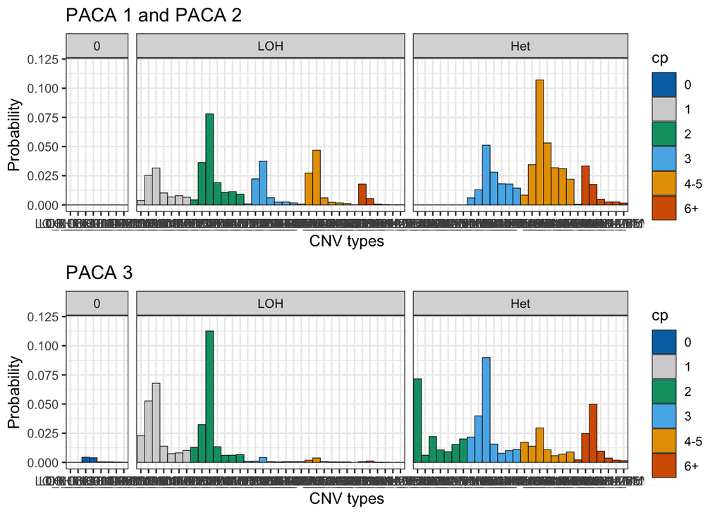

```r
ggarrange(PACA1.PACA2.CNV.sig.plot, PACA3.CNV.sig.plot, nrow = 2)
```

```r
# Save plot
pdf("./Rplots/PACA.CNV.signatures.pdf", width=6, height=6, useDingbats=FALSE)
ggarrange(PACA1.PACA2.CNV.sig.plot, PACA3.CNV.sig.plot, nrow = 2)
dev.off()
```

PACA 1/2 genomes are characterised by focal amplification (1-2 Mb).

## 2.4 Origin distribution at genomic break points

Compute the number of origins in 100 kb bins of the human genome.

In this section, we consider all constitutive origins.

```r
# r
library(rtracklayer)

# Load origin coordinates
ori.center.df <- read.table("./Dataset/ori/ori.center.hg19.NCBI.sorted.bed")
colnames(ori.center.df) <- c("seqnames", "start", "end", "EFF", "ori.id")
ori.center.gr <- makeGRangesFromDataFrame(ori.center.df, keep.extra.columns = T)
seqlevelsStyle(ori.center.gr) <- "UCSC"
# 23838 origins

# Count the number of origins in bins of 100kb
seqi_19  <- seqinfo(BSgenome.Hsapiens.UCSC.hg19)
hg19.100kb <- tileGenome(seqi_19, tilewidth = 100000, cut.last.tile.in.chrom = TRUE)
my.chr <- paste0("chr", c(1:22, "X", "Y"))
hg19.100kb <- hg19.100kb[seqnames(hg19.100kb) %in% my.chr]
ori.100kb.count.df <- as.data.frame(mergeByOverlaps(hg19.100kb, ori.center.gr)) %>%
  mutate(tile.id = paste(hg19.100kb.seqnames, hg19.100kb.start, hg19.100kb.end, sep = "_")) %>%
  group_by(tile.id) %>% summarise(ori.count = n()) %>%
  separate(tile.id, c("seqnames", "start", "end"))
ori.100kb.count.gr <- makeGRangesFromDataFrame(ori.100kb.count.df, keep.extra.columns = T)
saveRDS(ori.100kb.count.gr, file = "./004_Genome_rearrangements/rds/ori.100kb.count.gr.rds")
```

Compute matrices.

In this section, we consider only segments longer than 100 kb and smaller than 5 Mb.

Signal are corrected for background values. We hence assess origin excess from background.

```r
# r
library(EnrichedHeatmap)

# Load PACA CNV information and create grange objects
ICGC.PACA.CNA.df <- readRDS(file = "./004_Genome_rearrangements/rds/ICGC.PACA.CNA.df.rds")
ICGC.PACA.CNA.gr <- makeGRangesFromDataFrame(ICGC.PACA.CNA.df, keep.extra.columns = T)
seqlevelsStyle(ICGC.PACA.CNA.gr) <- "UCSC"

# Compute matrix for all segments
ori.CNA.segment.100kb.mat <-normalizeToMatrix(ori.100kb.count.gr, ICGC.PACA.CNA.gr, value_column = "ori.count", mean_mode = "weighted", extend = 2e6, w = 2e4, background = NA, target_ratio = 0.5)
saveRDS(ori.CNA.segment.100kb.mat, file = "./004_Genome_rearrangements/rds/ori.CNA.segment.100kb.mat.rds")

# Reload matrix
ori.CNA.segment.100kb.mat <- readRDS(file = "./004_Genome_rearrangements/rds/ori.CNA.segment.100kb.mat.rds")

# Compare PACA1/2 and PACA3
ICGC.PACA.CNA.join.df <- as.data.frame(ICGC.PACA.CNA.gr) %>% mutate(PACA = case_when(cluster == "clust.1" | cluster == "clust.2" ~ "PACA1/2", T ~ "PACA3"))

# At gained segments
ori.CNA.gain.segment.df <- as.data.frame(ori.CNA.segment.100kb.mat) %>%
  mutate(cluster = ICGC.PACA.CNA.join.df$PACA, width = width(ICGC.PACA.CNA.gr), copy.number = ICGC.PACA.CNA.gr$copy.number) %>%
  filter(copy.number >= 3) %>% filter(width >= 100000 & width <= 5000000) %>%
  dplyr::select(-width, -copy.number) %>% group_by(cluster) %>%
  summarise_all(~ sum(.x, na.rm = TRUE)) %>% t() %>% `colnames<-`(.[1, ]) %>% .[-1, ] %>% as_tibble() %>% mutate(bin = seq(1,400,1)) %>%
  mutate_if(is.character, as.numeric) %>%
  gather("cluster", "value", -bin) %>% ungroup() %>% group_by(cluster) %>% mutate(EXC = value-mean(value[c(1:80,220:400)]))
saveRDS(ori.CNA.gain.segment.df, file = "./004_Genome_rearrangements/rds/ori.CNA.gain.segment.df.rds")

# At copy neutral or loss segments
ori.CNA.loss.segment.df <- as.data.frame(ori.CNA.segment.100kb.mat) %>%
  mutate(cluster = ICGC.PACA.CNA.join.df$PACA, width = width(ICGC.PACA.CNA.gr), copy.number = ICGC.PACA.CNA.gr$copy.number) %>%
  filter(copy.number <= 2) %>% filter(width >= 100000 & width <= 5000000) %>%
  dplyr::select(-width, -copy.number) %>% group_by(cluster) %>%
  summarise_all(~ sum(.x, na.rm = TRUE)) %>% t() %>% `colnames<-`(.[1, ]) %>% .[-1, ] %>% as_tibble() %>% mutate(bin = seq(1,400,1)) %>%
  mutate_if(is.character, as.numeric) %>%
  gather("cluster", "value", -bin) %>% ungroup() %>% group_by(cluster) %>% mutate(EXC = value-mean(value[c(1:80,220:400)]))
saveRDS(ori.CNA.loss.segment.df, file = "./004_Genome_rearrangements/rds/ori.CNA.loss.segment.df.rds")

# Compare by copy number for PACA1/2 genomes
ori.CNA.copy.number.df <- as.data.frame(ori.CNA.segment.100kb.mat) %>%
  mutate(cluster = ICGC.PACA.CNA.join.df$PACA, width = width(ICGC.PACA.CNA.gr), copy.number = ICGC.PACA.CNA.gr$copy.number) %>%
  filter(cluster == "PACA1/2" & copy.number >= 3) %>% filter(width >= 100000 & width <= 5000000) %>%
  dplyr::select(-cluster, -width) %>% group_by(copy.number) %>%
  summarise_all(~ sum(.x, na.rm = TRUE)) %>% t() %>% `colnames<-`(.[1, ]) %>% .[-1, ] %>% as_tibble() %>% mutate(bin = seq(1,400,1)) %>%
  mutate_if(is.character, as.numeric) %>%
  gather("copy.number", "value", -bin) %>% ungroup() %>% group_by(copy.number) %>% mutate(EXC = value-mean(value[c(1:80,220:400)]))
saveRDS(ori.CNA.copy.number.df, file = "./004_Genome_rearrangements/rds/ori.CNA.copy.number.df.rds")

# Compare fragments of 4 copy number for LOH and Het in PACA1/2 genomes
ori.CNA.mutation.type.df <- as.data.frame(ori.CNA.segment.100kb.mat) %>%
  mutate(cluster = ICGC.PACA.CNA.join.df$PACA, width = width(ICGC.PACA.CNA.gr), copy.number = ICGC.PACA.CNA.gr$copy.number, mutation.type = ICGC.PACA.CNA.gr$mutation.type) %>%
  filter(cluster == "PACA1/2" & copy.number == 4) %>% filter(width >= 100000 & width <= 5000000) %>%
  dplyr::select(-cluster, -width, -copy.number) %>% group_by(mutation.type) %>%
  summarise_all(~ sum(.x, na.rm = TRUE)) %>% t() %>% `colnames<-`(.[1, ]) %>% .[-1, ] %>% as_tibble() %>% mutate(bin = seq(1,400,1)) %>%
  mutate_if(is.character, as.numeric) %>%
  gather("mutation.type", "value", -bin) %>% ungroup() %>% group_by(mutation.type) %>% mutate(EXC = value-mean(value[c(1:80,220:400)]))
saveRDS(ori.CNA.mutation.type.df, file = "./004_Genome_rearrangements/rds/ori.CNA.mutation.type.df.rds")
```

Plot results

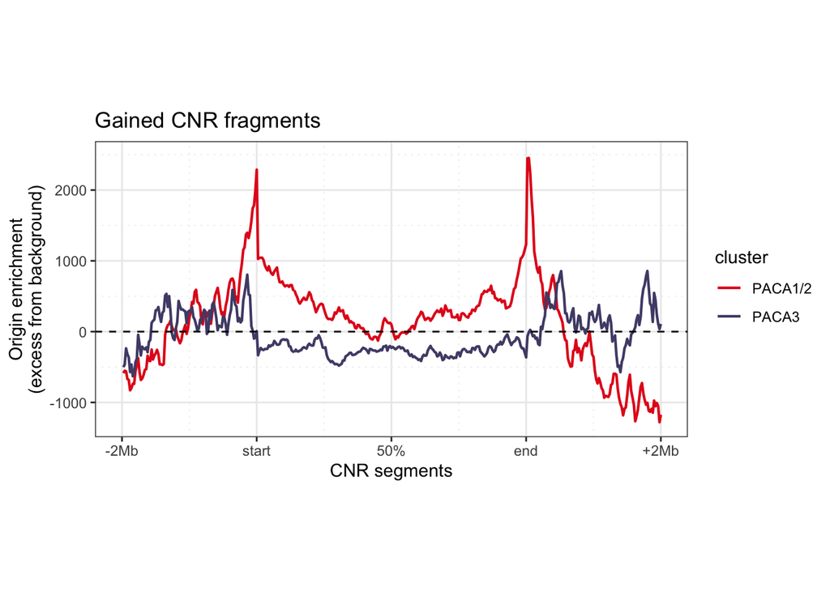

```r
library(dplyr)
library(tidyr)
library(ggplot2)
library(forcats)
library(ggpubr)
setwd("/Users/pm23/Desktop/Projects/OriCan")

# Compare PACA1/2 and PACA3

# At gained segments

ori.CNA.gain.segment.df <- readRDS("./004_Genome_rearrangements/rds/ori.CNA.gain.segment.df.rds")
ori.CNA.gain.segment.plot <- ori.CNA.gain.segment.df %>% ggplot(aes(x=bin, y=EXC, col=cluster)) +
  geom_line(size = 0.75) + ylab("Origin enrichment\n(excess from background)") + ggtitle("Gained CNR fragments") +
  theme_bw() + theme(aspect.ratio=0.5, panel.grid.minor = element_line(linetype = "dotted")) +
  scale_color_manual(values = c("#E4221E", "#504B76")) +
  geom_hline(yintercept=0, linetype="dashed") + ylim(-1300, 2500) +
  scale_x_continuous(name="CNR segments", limits=c(0, 400), n.breaks = 6, labels = c("-2Mb", "start", "50%", "end", "+2Mb"))
ori.CNA.gain.segment.plot
```

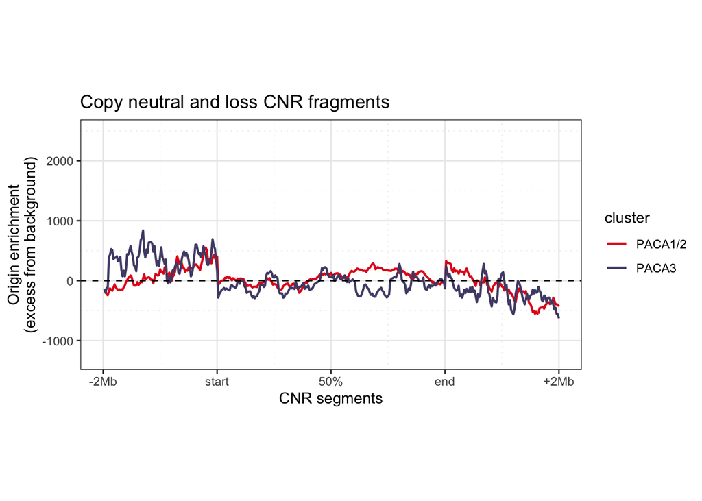

```r
# At copy neutral or loss segments

ori.CNA.loss.segment.df <- readRDS("./004_Genome_rearrangements/rds/ori.CNA.loss.segment.df.rds")
ori.CNA.loss.segment.plot <- ori.CNA.loss.segment.df %>% ggplot(aes(x=bin, y=EXC, col=cluster)) +
  geom_line(size = 0.75) + ylab("Origin enrichment\n(excess from background)") + ggtitle("Copy neutral and loss CNR fragments") +
  theme_bw() + theme(aspect.ratio=0.5, panel.grid.minor = element_line(linetype = "dotted")) +
  scale_color_manual(values = c("#E4221E", "#504B76")) +
  geom_hline(yintercept=0, linetype="dashed") + ylim(-1300, 2500) +
  scale_x_continuous(name="CNR segments", limits=c(0, 400), n.breaks = 6, labels = c("-2Mb", "start", "50%", "end", "+2Mb"))
ori.CNA.loss.segment.plot
```

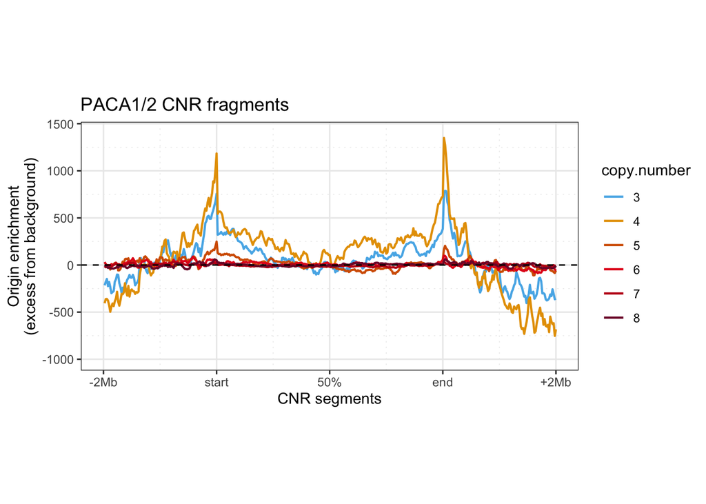

```r
# Compare PACA1/2 fragments for different copy number

ori.CNA.copy.number.df <- readRDS("./004_Genome_rearrangements/rds/ori.CNA.copy.number.df.rds")
ori.CNA.copy.number.plot <- ori.CNA.copy.number.df %>% ggplot(aes(x=bin, y=EXC, col=copy.number)) +
  geom_line(size = 0.75) + ylab("Origin enrichment\n(excess from background)") + ggtitle("PACA1/2 CNR fragments") +
  theme_bw() + theme(aspect.ratio=0.5, panel.grid.minor = element_line(linetype = "dotted")) +
  scale_color_manual(values = c("#56B4E9", "#E69F00", "#D55E00", "#E4221E", "#C01818", "#7E1333")) +
  geom_hline(yintercept=0, linetype="dashed") + ylim(-1000, 1400) +
  scale_x_continuous(name="CNR segments", limits=c(0, 400), n.breaks = 6, labels = c("-2Mb", "start", "50%", "end", "+2Mb"))
ori.CNA.copy.number.plot
```

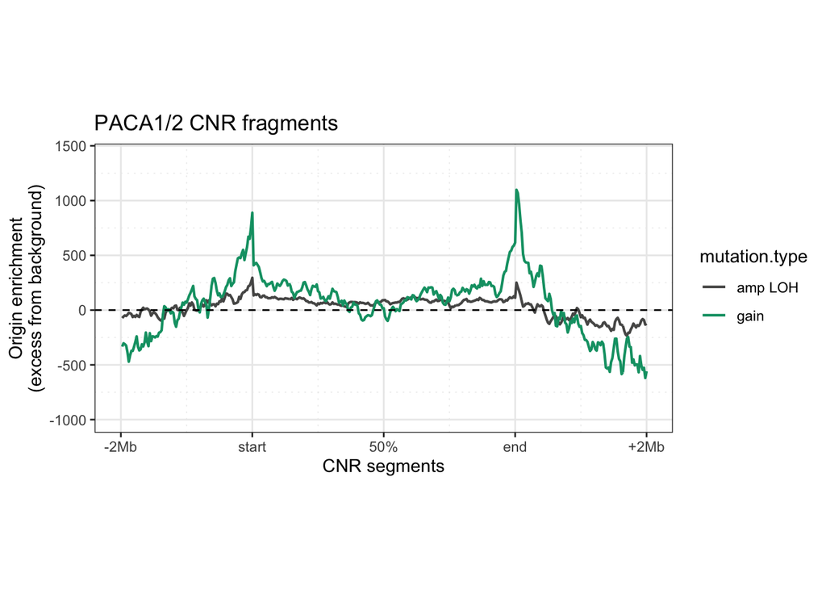

```r
# Compare fragments of 4 copy number for LOH and Het in PACA1/2 genomes

ori.CNA.mutation.type.df <- readRDS("./004_Genome_rearrangements/rds/ori.CNA.mutation.type.df.rds")
ori.CNA.mutation.type.plot <- ori.CNA.mutation.type.df %>% ggplot(aes(x=bin, y=EXC, col=mutation.type)) +
  geom_line(size = 0.75) + ylab("Origin enrichment\n(excess from background)") + ggtitle("PACA1/2 CNR fragments") +
  theme_bw() + theme(aspect.ratio=0.5, panel.grid.minor = element_line(linetype = "dotted")) +
  scale_color_manual(values = c("#575756", "#069F73")) +
  geom_hline(yintercept=0, linetype="dashed") + ylim(-1000, 1400) +
  scale_x_continuous(name="CNR segments", limits=c(0, 400), n.breaks = 6, labels = c("-2Mb", "start", "50%", "end", "+2Mb"))
ori.CNA.mutation.type.plot
```

```r
pdf("./Rplots/PACA.ori.CNV.pdf", width=6, height=10, useDingbats=FALSE)
ggarrange(ori.CNA.gain.segment.plot, ori.CNA.loss.segment.plot, ori.CNA.copy.number.plot, ori.CNA.mutation.type.plot, nrow = 4)
dev.off()
```

## 2.5 Origin enrichment at PACA break points

Use of permutation tests to assess enrichment of origins at CNV break points in PACA genomes

```r
# r
library(rtracklayer)
library(dplyr)
library(regioneR)
setwd("/cephfs2/pmurat/OriCan")

# Load PACA CNV information and create grange objects
ICGC.PACA.CNA.df <- readRDS(file = "./004_Genome_rearrangements/rds/ICGC.PACA.CNA.df.rds")
ICGC.PACA.CNA.gr <- makeGRangesFromDataFrame(ICGC.PACA.CNA.df, keep.extra.columns = T)
seqlevelsStyle(ICGC.PACA.CNA.gr) <- "UCSC"

# Select gain segments for PACA1/2 genomes of the appropriate length
donor.PACA.1.2 <- unique(c(ICGC.PACA.CNA.gr[ICGC.PACA.CNA.gr$cluster == "clust.1"]$donor, ICGC.PACA.CNA.gr[ICGC.PACA.CNA.gr$cluster == "clust.1"]$donor))
ICGC.PACA.1.2.gain.CNA.gr <- ICGC.PACA.CNA.gr[(ICGC.PACA.CNA.gr$donor %in% donor.PACA.1.2) & ICGC.PACA.CNA.gr$copy.number >= 3 & width(ICGC.PACA.CNA.gr) >= 100000 & width(ICGC.PACA.CNA.gr) <= 5000000]
# 19780 segments

# Recover CNV boundaries
ICGC.PACA.1.2.start.gr <- resize(ICGC.PACA.1.2.gain.CNA.gr, 1, fix = "start")
ICGC.PACA.1.2.end.gr <- resize(ICGC.PACA.1.2.gain.CNA.gr, 1, fix = "end")
  ICGC.PACA.1.2.bound.gr <- reduce(c(ICGC.PACA.1.2.start.gr, ICGC.PACA.1.2.end.gr))

# Load origin coordinates
ori.df <- read.table("./Dataset/ori/ori.center.hg19.NCBI.sorted.bed")
colnames(ori.df) <- c("seqnames", "start", "end", "EFF", "ori.id")
ori.gr <- makeGRangesFromDataFrame(ori.df, keep.extra.columns = T)
seqlevelsStyle(ori.gr) <- "UCSC"
# Add 500 bp flanks
ori.gr <- ori.gr + 500

numOverlaps(ICGC.PACA.1.2.bound.gr, ori.gr, count.once=TRUE) # 539 boundaries

permut.PACA.1.2.pt <- overlapPermTest(ICGC.PACA.1.2.bound.gr, ori.gr, ntimes=1000, count.once=TRUE)
saveRDS(permut.PACA.1.2.pt, file = "./004_Genome_rearrangements/rds/permut.PACA.1.2.pt.rds")
```

Plot result of permutation test

Plot results

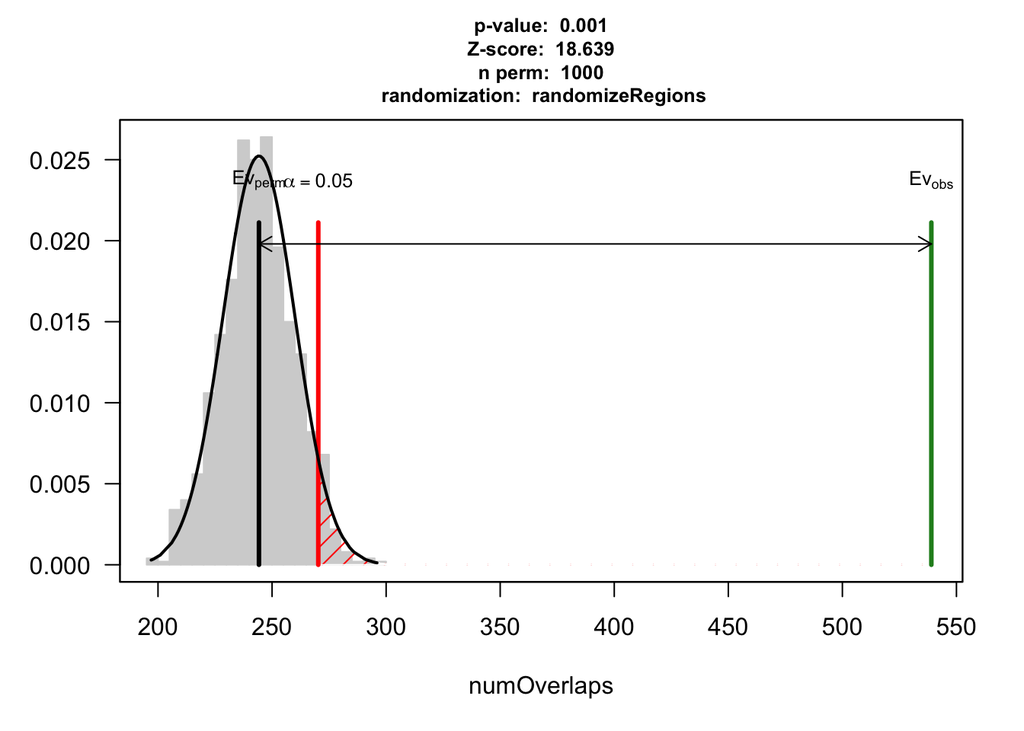

```r
library(dplyr)
library(regioneR)
setwd("/Users/pm23/Desktop/Projects/OriCan")

permut.PACA.1.2.pt <- readRDS(file = "./004_Genome_rearrangements/rds/permut.PACA.1.2.pt.rds")
plot(permut.PACA.1.2.pt)
```

```r
pdf("./Rplots/PACA.ori.CNV.permutation.pdf", width=6, height=4, useDingbats=FALSE)
plot(permut.PACA.1.2.pt)
dev.off()
```

## 2.6 Functional consequences of origin-mediated CNA

Assess the overlap between CNR segments with origin at boundaries and genes.

```r
# Recover segments with origin boundaries

# Load PACA CNV information and create grange objects
ICGC.PACA.CNA.df <- readRDS(file = "./004_Genome_rearrangements/rds/ICGC.PACA.CNA.df.rds")

# Select segment of interest and add ids
ICGC.PACA.CNA.filter.df <- ICGC.PACA.CNA.df %>%
  filter(copy.number == 4 & (cluster == "clust.1" | cluster == "clust.2") & (end - start) >= 100000 & (end - start) <= 5000000) %>%
  mutate(CNV.id = paste(seqnames, start, end, sep = "_"))
ICGC.PACA.CNA.filter.gr <- makeGRangesFromDataFrame(ICGC.PACA.CNA.filter.df, keep.extra.columns = T)
seqlevelsStyle(ICGC.PACA.CNA.filter.gr) <- "UCSC"

# Recover segment boundaries
ICGC.PACA.CNA.filter.start.gr <- resize(ICGC.PACA.CNA.filter.gr, 1, fix = "start")
ICGC.PACA.CNA.filter.end.gr <- resize(ICGC.PACA.CNA.filter.gr, 1, fix = "end")
seqlevelsStyle(ICGC.PACA.CNA.filter.start.gr) <- "UCSC"
seqlevelsStyle(ICGC.PACA.CNA.filter.end.gr) <- "UCSC"

# Identify boundaries overlapping with origins
ICGC.PACA.CNA.filter.start.ori.overlap.gr <- subsetByOverlaps(ICGC.PACA.CNA.filter.start.gr, ori.gr) # 302 segments
ICGC.PACA.CNA.filter.end.ori.overlap.gr <- subsetByOverlaps(ICGC.PACA.CNA.filter.end.gr, ori.gr) # 293 segments
ori.CNV.id <- unique(c(ICGC.PACA.CNA.filter.start.ori.overlap.gr$CNV.id, ICGC.PACA.CNA.filter.end.ori.overlap.gr$CNV.id)) # 566 segments

# Filter segments of interest
ICGC.PACA.CNA.ori.gr <- ICGC.PACA.CNA.filter.gr[ICGC.PACA.CNA.filter.gr$CNV.id %in% ori.CNV.id]

# Compute distance to genes
CNV.gene.nearest <- distanceToNearest(ICGC.PACA.CNA.ori.gr, hsapiens.coding.genes.gr)
CNV.gene.nearest.df <- cbind.data.frame(as.data.frame(ICGC.PACA.CNA.ori.gr), ncbi.gene.id = as.numeric(hsapiens.coding.genes.gr[subjectHits(CNV.gene.nearest)]$gene_id), dist = CNV.gene.nearest@elementMetadata$distance) %>% left_join(hsapiens.coding.genes, by = "ncbi.gene.id")
saveRDS(CNV.gene.nearest.df, file = "./004_Genome_rearrangements/rds/CNV.gene.nearest.df.rds")

# Compute gene occurence
CNV.occ.df <- CNV.gene.nearest.df %>% group_by(gene.symbol) %>% summarise(count = n())
```

List of potential functional origin-associated CNVs comprises: - 300-800kb CNAs overlapping SOX11 in 5 independent donors. SOX11 is overexpressed in pancreatic neoplasms (https://pubmed.ncbi.nlm.nih.gov/29272888/). - 700kb to 2.7Mb CNAs overlapping CDK11B in 4 independent donors. This kinase targets cyclin B that control G2/M transition. - 900kb to 1.2Mb CNAs overlapping EIF3B in 4 independent donors. EIF3B promotes cancer progression in pancreatic cancer (https://www.tandfonline.com/doi/full/10.1080/00365521.2020.1868566). - 900kb to 2.4Mb CNAs overlapping MTA1 in 4 independent donors. MTA1 promotes the invasion and migration of pancreatic cancer cells (metastasis, https://pubmed.ncbi.nlm.nih.gov/30396299/). - a 1.2Mb CNAs overlapping BRCA2 in 2 independent donors.